# Temperatur und Wetter in Kiel

Julian Berger

18.05.2021

### Einleitung

In dieser Arbeit werden historische Klima- und Wetterdaten von Kiel analysiert und mit heutigen Daten verglichen. Dabei wird ein besonderes Augenmerk auf die Veränderung der Extremtemperaturen zwischen den Daten vor 1950 und der heutigen Zeit gelegt. Es stellt sich hierbei die Frage, ob es einen Effekt des Klimawandels zu entdecken gibt, den man mit relativ einfachen Analysen entdecken und visualisieren kann. Andere Studien zum Klimawandel sind meistens aufwendiger und betrachten größere Bereiche als nur eine Landeshauptstadt von der Größe Kiels. Dazu kommt, dass eine Analyse eines einzelnen Ortes auch auf andere Faktoren als einen globalen Klimawandel zurückzuführen sein könnte. Die Ergebnisse dienen insofern nicht zur Bestätigung oder Ablehnung des Klimawandels, sondern sind hauptsächlich als Ergebnis einer Prüfungsleistung zum Thema Datenvisualisierung gedacht.

### Einbinden der Bibliotheken

```r
library(tidyverse)
library(dplyr)
library(saqgetr)
library(leaflet)
library(rdwd)
library(lubridate)
library(kableExtra)
library(plotly)
library(gridExtra)
```

### Daten einlesen

Die Daten für diese Arbeit stammen vom Deutschen Wetterdienst (DWD). Mittels des *rdwd* packages können aus der Datenbank des DWD historische Wetterdaten und Temperaturmessungen aus ganz Deutschland eingelesen werden.

Für Kiel gibt es drei Wetterstationen, die historische Daten liefern. Mittels der *data* Funktion können die Metainformationen aus dem rdwd-Package angesehen werden. Darin finden sich die drei Stationen Kiel-Holtenau, Kiel-Kronshagen und Leuchtturm Kiel.

Im nächsten Absatz werden zunächst alle Wetterdaten aus diesen drei Stationen in täglicher Auflösung eingelesen und in einem Dataframe gespeichert.

### Wie viele sehr heiße Tage?

In diesem Abschnitt wird untersucht, wie viele sehr heiße Tage es in jedem Jahr gab.

Nach dem Join wird eine extra Spalte erzeugt, in der die maximale Tagestemperatur von Kiel-Holtenau oder Kiel-Kronshagen gespeichert wird, je nachdem, welche zur Verfügung steht. Dabei entsteht eine Datenlücke in den Jahren zwischen 2000 und 2005.

Auffällig ist, neben der oben erwähnten Lücke, der lange, heiße Zeitraum der beiden Jahre 1975 und 1976. Es ist kein eindeutiger Trend zu erkennen, demzufolge die Anzahl der heißen Tage im Jahr seit 1940 stetig zu genommen hätte. Trotzdem fällt auf, dass es seit 1980 deutlich mehr Jahre gegeben hat, in denen die Temperatur häufiger als zehn Mal im Jahr über 25 Grad gelegen hat. Auch das heißeste Jahr fand in der heutigen Zeit, im Jahr 2018 statt, in dem es fast 40 heiße Tage gab.

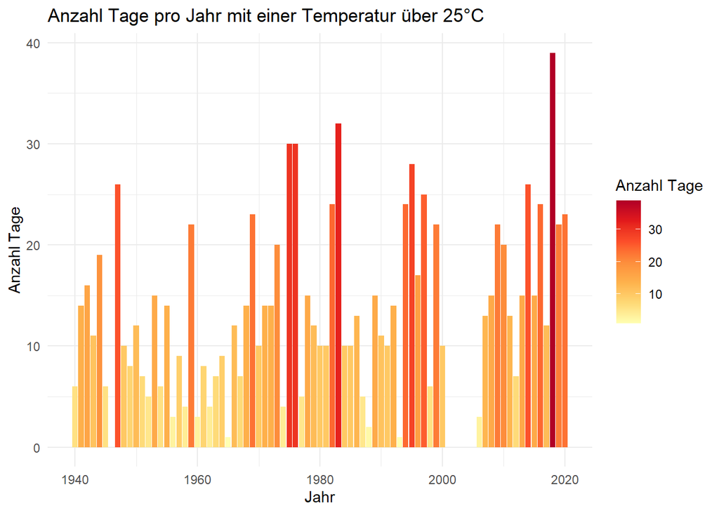

### Wie viele sehr kalte Tage?

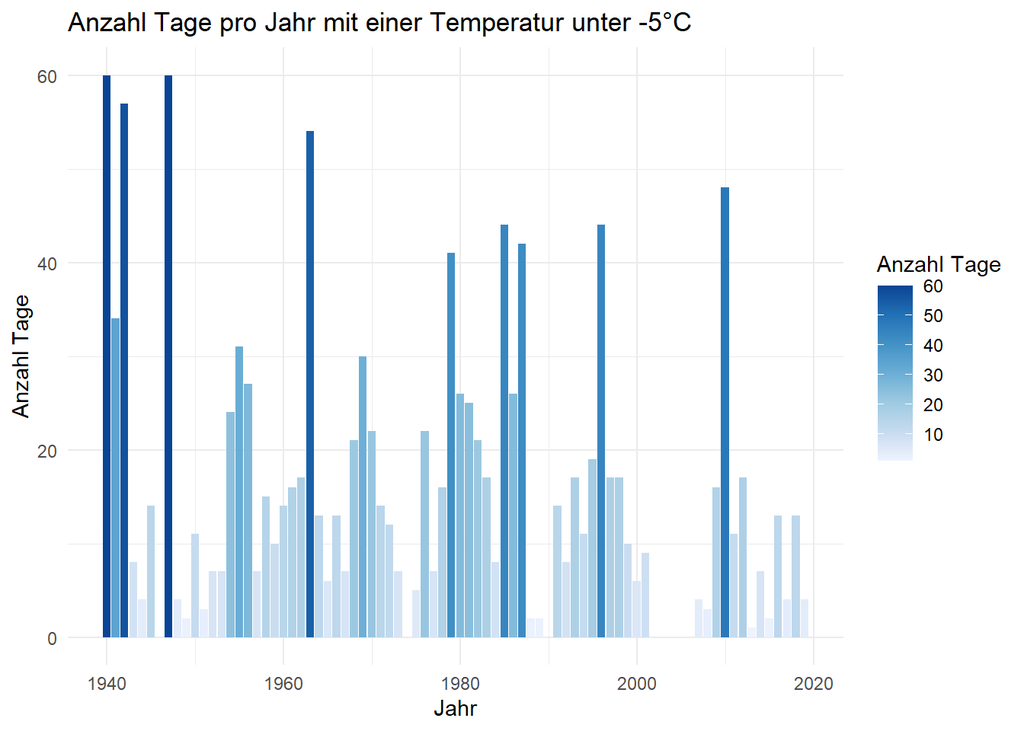

### Durchschnittliche Monatstemperatur

Es zeigt sich, dass die Durchschnittstemperatur in den 70 Jahren um bis zu 3°C gestiegen ist. Besonders in den Wintermonaten Januar und Februar ist der Unterschied auffällig, da die Durchschnittstemperatur ins Positive gestiegen ist. Dies verstärkt den zuvor gewonnenen Eindruck, dass das Wetter in Kiel immer wärmer wird.

Auflistung über die monatlichen Abweichungen der Durchschnittstemperatur der beiden Messstationen Kiel-Holtenau und Kiel-Kronshagen

| Monat | Durchschnittliche Abweichung (°C) |
| --- | --- |
| Jan | 0.03 |
| Feb | -0.10 |
| Mrz | -0.11 |
| Apr | -0.51 |
| Mai | -0.52 |
| Jun | -0.27 |
| Jul | -0.06 |
| Aug | -0.14 |
| Sep | 0.16 |
| Okt | 0.29 |
| Nov | 0.07 |
| Dez | 0.09 |

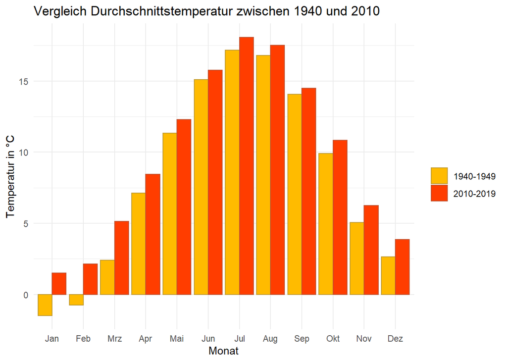

### Welche Temperatur kann man in Kiel erwarten?

In diesem Abschnitt werden die letzten 20 Jahre der Temperaturmessung in Kiel-Holtenau ausgewertet. Dabei wird die durschnittliche tägliche Maximaltemperatur und Minimaltemperatur für jeden Monat ausgewertet und ausgegeben. Zusätzlich wird die durchschnittliche Maximaltemperatur und Minimaltemperatur des Zeitraums zwischen 1940 und 1960 ausgewertet und dargestellt. Der Verlauf der Jahr 1940 bis 1960 ist dabei in blasser Farbe gezeichnet, damit der Unterschied erkennbar ist, aber nicht störend wirkt. Auch hier wird deutlich, dass die kalten Monate wärmer werden und die heißen Monate heißer. Einzig die Minimaltemperatur im Sommer bleibt unverändert.

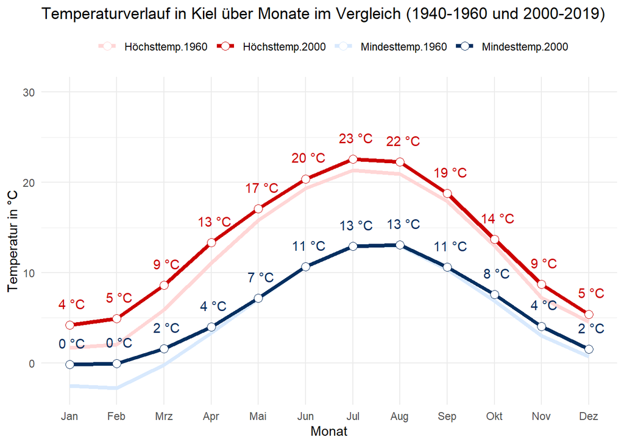

### Fazit

Verschiedene Analysen der Temperaturdaten in Kiel haben gezeigt, dass es in Kiel immer wärmer wird. Seit der Jahrtausendwende gab es nur noch zwei Jahre, in denen die Maximaltemperatur seltener als zehn mal pro Jahr die Marke von 25°C überschritten hat. Zwischen 1940 und 1960 geschah dies noch in 11 Jahren.

Auch die monatliche Durchschnittstemperatur ist seit den 40er Jahren deutlich gestiegen. Während diese im Januar zwischen 1940 und 1949 noch bei -1.5°C lag, stieg diese in den Jahren zwischen 2010 und 2019 auf 1.5°C. Auch im Sommer ist der Unterschied bemerkbar, liegt aber nur noch bei knapp unter 1°C.

Die durchschnittlichen monatlichen Maximal- und Minimaltemperaturen sind zwischen 1940-1959 und dem Zeitraum seit der Jahrtausenwende auch in fast jedem Monat angestiegen.